# (Ford gobike Data Analysis)

#### Saturday has longer average trip duration

```python
df_clean.start_hr.describe()
```

```
count    168179.000000
mean         13.449688
std           4.747748
min           0.000000
25%           9.000000
50%          14.000000
75%          17.000000
max          23.000000
Name: start_hr, dtype: float64
```

```python
df_clean.groupby('day_of_week')['start_hr'].mean()
```

```
day_of_week
Fri    12.803779
Mon    13.405367
Sat    13.665604
Sun    14.204240
Thu    13.595189
Tue    13.233618
Wed    13.703997
Name: start_hr, dtype: float64
```

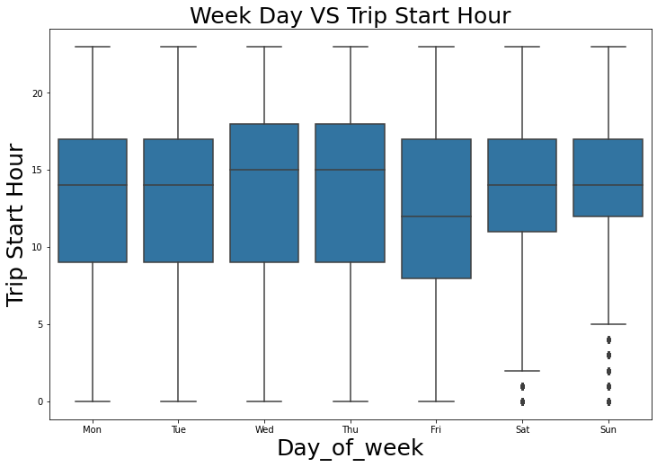

```python
plt.figure(figsize=(12,8))
day_order = ['Mon', 'Tue', 'Wed', 'Thu', 'Fri', 'Sat', 'Sun']
sb.boxplot(df_clean.day_of_week, df_clean.start_hr, color=base_color, order=day_order)
plt.xlabel('Day_of_week', fontsize=25)
plt.ylabel('Trip Start Hour', fontsize=25)
plt.title('Week Day VS Trip Start Hour', fontsize=25);
```

#### All days have almost the same start hour but the median for friday looks alittle bit earlier, Users start early at fridays and finish late at wensday and thursday.

```
count    168179.000000
mean         13.449688
std           4.747748
min           0.000000
25%           9.000000
50%          14.000000
75%          17.000000
max          23.000000
Name: start_hr, dtype: float64
```

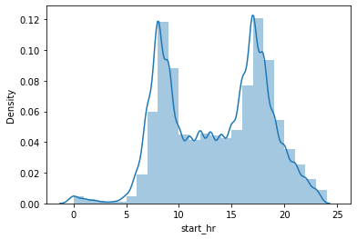

```python
# Peak hours for the service
display(df_clean.start_hr.describe())
bin_1 = np.arange(0, 25+1, 1)
sb.distplot(df_clean.start_hr, bins = bin_1)
plt.xticks([ 0, 5, 10, 15, 20, 25]);
```

#### Most of users start using the service from 6 morning till 10 am the first peak then moderate usage then another peak at noon around 4pm till 7pm the second peak then gradually stop at midnight till morning.

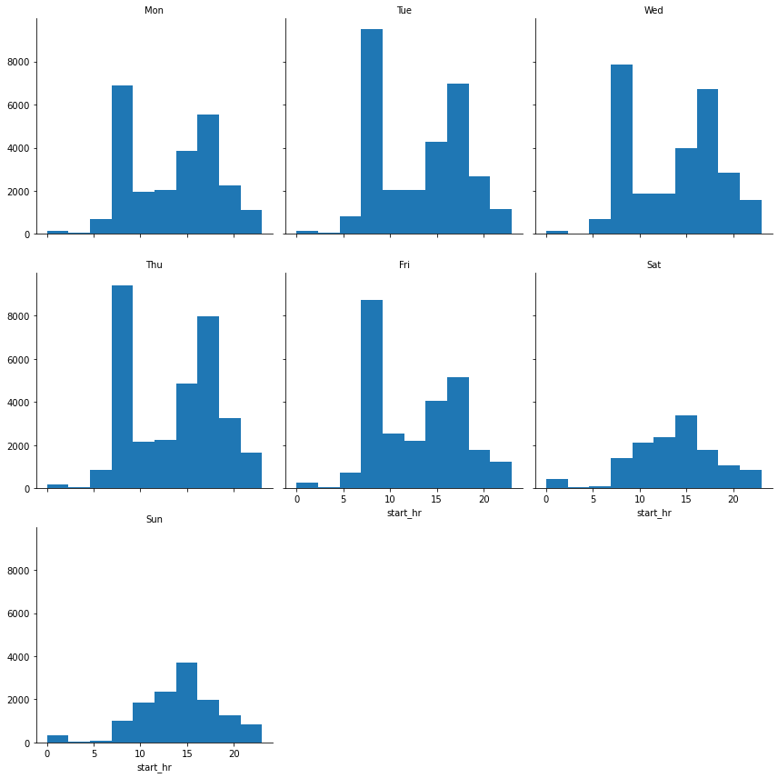

```python
plt.figure(figsize=(10,10))
g =sb.FacetGrid(data=df_clean, col='day_of_week', col_wrap=3, size=4, col_order=day_order)
g.map(plt.hist, 'start_hr', bins=10)
g.set_titles('{col_name}');
```

#### It seem that start hours are almost the same most of the week except for sunday and saturday they dont have peak hours at morning and afternoon.

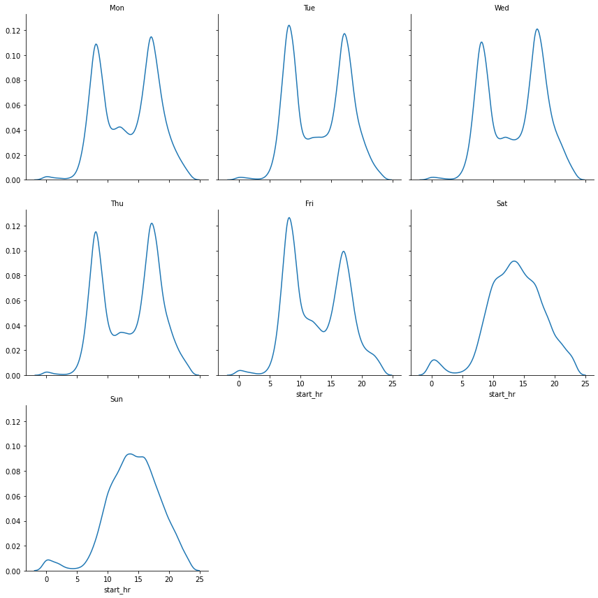

```python
plt.figure(figsize=(10,10))
g =sb.FacetGrid(data=df_clean, col='day_of_week', col_wrap=3, size=4, col_order=day_order)
g.map(sb.kdeplot, 'start_hr')
g.set_titles('{col_name}');
```

#### It seem that start hours are almost the same most of the week except for sunday and saturday they dont have peak hours at morning and afternoon, at saturday and sunday it looks normal distrubtion for start hours.

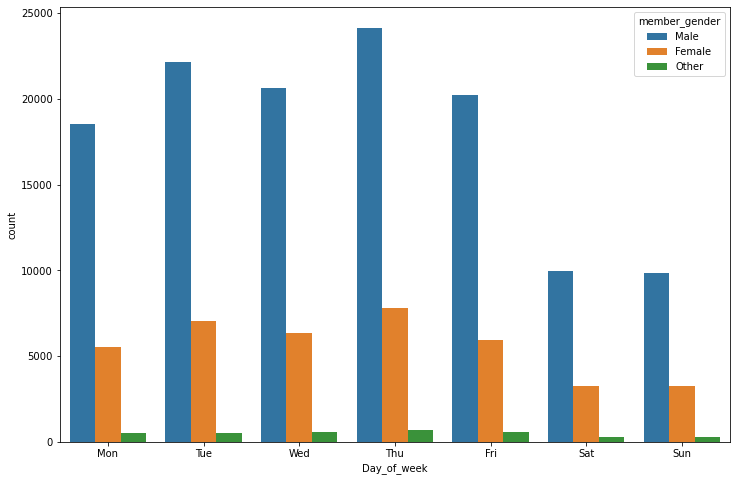

```python
plt.figure(figsize=(12, 8))
day_order = ['Mon', 'Tue', 'Wed', 'Thu', 'Fri', 'Sat', 'Sun']
g = sb.countplot(data=df_clean, x="day_of_week", hue="member_gender", order=day_order)
g.set_xlabel('Day_of_week');
```

#### Data biased towards men as they are the most users of the service.

### Talk about some of the relationships you observed in this part of the investigation. How did the feature(s) of interest vary with other features in the dataset?

> I found a good relation ship between trip start hour and days of the week

> Men are the most users

> Saturday has longer average trip duration

### Did you observe any interesting relationships between the other features (not the main feature(s) of interest)?

> Men and women both have the same pattern for trip start hour.

> Peak hours are at morning and afternoon except for sunday and saturday

## Multivariate Exploration

> Create plots of three or more variables to investigate your data even further. Make sure that your investigations are justified, and follow from your work in the previous sections.

```python
df_clean.head()
```

|  | duration_min | duration_hr | day_of_week | start_hr | start_station_id | end_station_id | member_gender | age | user_type | bike_share_for_all_trip | age_group |
| --- | --- | --- | --- | --- | --- | --- | --- | --- | --- | --- | --- |
| 4 | 26.416667 | 0.440278 | Thu | 23 | 7.0 | 222.0 | Male | 45.0 | Subscriber | Yes | 38 - 48 |
| 5 | 29.883333 | 0.498056 | Thu | 23 | 93.0 | 323.0 | Male | 60.0 | Subscriber | No | 48 - 58 |
| 6 | 19.116667 | 0.318611 | Thu | 23 | 300.0 | 312.0 | Female | 36.0 | Subscriber | No | 28 - 38 |
| 7 | 26.916667 | 0.448611 | Thu | 23 | 10.0 | 127.0 | Male | 30.0 | Subscriber | No | 18 - 28 |
| 8 | 26.166667 | 0.436111 | Thu | 23 | 10.0 | 127.0 | Other | 31.0 | Subscriber | No | 28 - 38 |

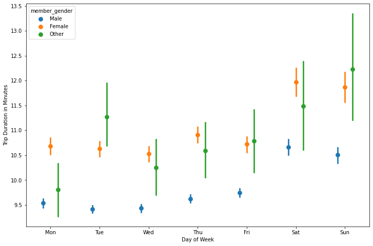

```python
plt.figure(figsize=(12, 8))
sb.pointplot(data=df_clean, x='day_of_week', y='duration_min', hue='member_gender', dodge=0.3, linestyles="", order=day_order);
plt.xlabel('Day of Week');
plt.ylabel('Trip Duration in Minutes');
```

#### Females are taking longer time at trip duration.

#### Males and females are taking longer trips at saturday and sunday.

[figure not shown]

```python
g = sb.FacetGrid(data = df_clean, col = 'member_gender', col_wrap = 2, size = 5,
                 xlim = [10, 70], ylim = [1, 50])
g.map(plt.scatter, 'age', 'duration_min', alpha= 0.25)

g.set_xlabels('Age')
g.set_ylabels('Duration_min');
```

#### Older men taking less time and duration compared to older women

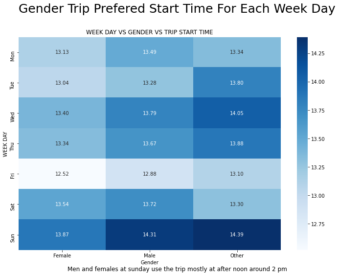

```python
# SET WEEKDAY ORDER

df_clean['day_of_week'] = pd.Categorical(df_clean.day_of_week, categories=['Mon','Tue','Wed','Thu','Fri','Sat', 'Sun'], ordered=True)
fig = plt.figure(figsize=(12,8))

t3 = pd.pivot_table(df_clean, 'start_hr', 'day_of_week', 'member_gender')
plt.suptitle('Gender Trip Prefered Start Time For Each Week Day', y=1, fontsize=25)
sb.heatmap(t3, cmap='Blues', annot=True, fmt='.2f' )

plt.title('WEEK DAY VS GENDER VS TRIP START TIME', fontsize=12)
plt.xlabel('Gender')
plt.ylabel('WEEK DAY')
fig.text(0.5, .05, 'Men and females at sunday use the trip mostly at after noon around 2 pm', horizontalalignment='center', fontsize=12, ha='center');
```

#### Men and females at sunday use the trip mostly at after noon around 2 pm

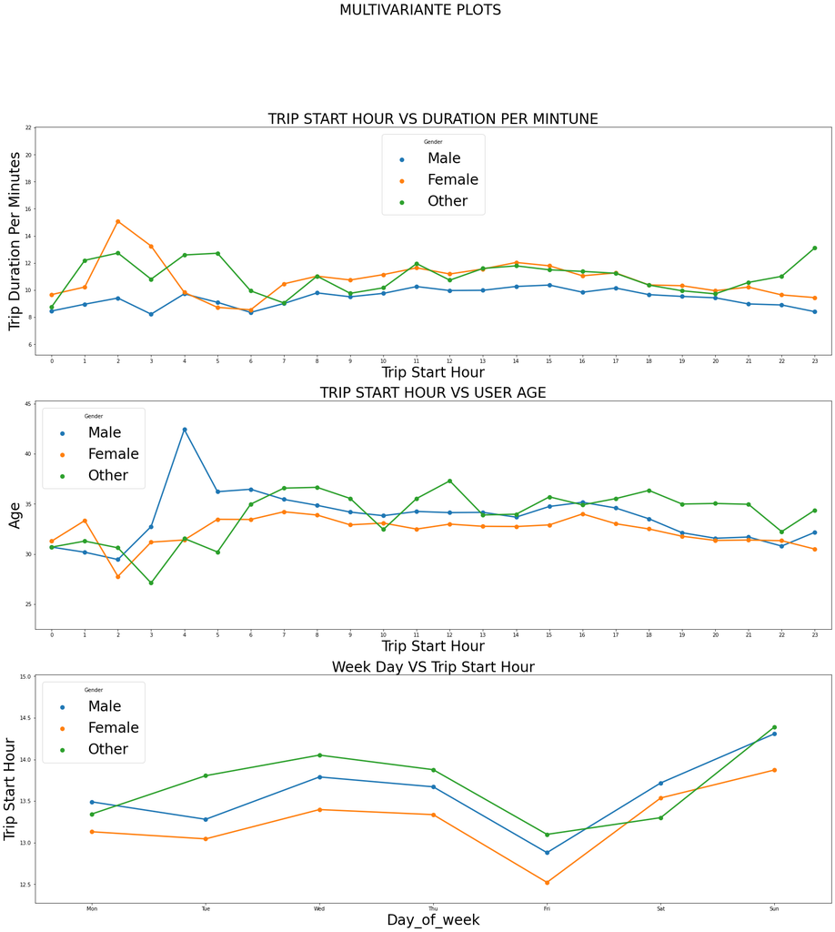

```python
fig = plt.figure(figsize=[28, 28])

fig.suptitle('MULTIVARIANTE PLOTS', fontsize=28,  y = 1 )

plt.subplot(3, 1, 1)
sb.pointplot(data=df_clean, x='start_hr', y='duration_min', hue='member_gender', errwidth=0)
plt.xlabel('Trip Start Hour', fontsize=28)
plt.ylabel('Trip Duration Per Minutes', fontsize=28)
plt.title('TRIP START HOUR VS DURATION PER MINTUNE', fontsize=28)
plt.legend(title='Gender', fontsize=28);

plt.subplot(3, 1, 2)
sb.pointplot(data=df_clean, x='start_hr', y='age', hue='member_gender', errwidth=0)
plt.xlabel('Trip Start Hour', fontsize=28)
plt.ylabel('Age', fontsize=28)
plt.title('TRIP START HOUR VS USER AGE', fontsize=28)
plt.legend(title='Gender', fontsize=28);

plt.subplot(3, 1, 3)
sb.pointplot(data=df_clean, x='day_of_week', y='start_hr', hue='member_gender', errwidth=0)
plt.xlabel('Day_of_week', fontsize=28)
plt.ylabel('Trip Start Hour', fontsize=28)
plt.title('Week Day VS Trip Start Hour', fontsize=28)
plt.legend(title='Gender', fontsize=28);
```

### Talk about some of the relationships you observed in this part of the investigation. Were there features that strengthened each other in terms of looking at your feature(s) of interest?

> Females start early than males.

> Both females and males start trips early at fridays

> Older men are starting trips earlier than other age groups

> Females trip duration is longer

> Males and females are taking longer trips at saturday and sunday.

### Were there any interesting or surprising interactions between features?

> Older men starts trips early

> Women takes longer time at trips

> Time peaks at morning and afternoon

> At the end of your report, make sure that you export the notebook as an html file from the `File > Download as... > HTML` menu. Make sure you keep track of where the exported file goes, so you can put it in the same folder as this notebook for project submission. Also, make sure you remove all of the quote-formatted guide notes like this one before you finish your report!

```python
# Save the new clean data set to a new csv file
df_clean.to_csv('gofordbike_clean.csv',  index = False)
```